# Risk Factor Analysis

## Outcome Variable

**Outcome Variable:** stunted

## Predictor Variables

**Intervention Variable:** gagebrth

**Adjustment Set:**

unadjusted

## Stratifying Variables

The analysis was stratified on these variable(s):

- agecat
- studyid
- country

## Data Summary

| agecat | studyid | country | gagebrth | stunted | n_cell | n |
| --- | --- | --- | --- | --- | --- | --- |
| Birth | ki1000108-CMC-V-BCS-2002 | INDIA | Full or late term | 0 | 48 | 92 |
| Birth | ki1000108-CMC-V-BCS-2002 | INDIA | Full or late term | 1 | 10 | 92 |
| Birth | ki1000108-CMC-V-BCS-2002 | INDIA | Preterm | 0 | 8 | 92 |
| Birth | ki1000108-CMC-V-BCS-2002 | INDIA | Preterm | 1 | 3 | 92 |
| Birth | ki1000108-CMC-V-BCS-2002 | INDIA | Early term | 0 | 19 | 92 |
| Birth | ki1000108-CMC-V-BCS-2002 | INDIA | Early term | 1 | 4 | 92 |
| Birth | ki1000108-IRC | INDIA | Full or late term | 0 | 211 | 369 |
| Birth | ki1000108-IRC | INDIA | Full or late term | 1 | 27 | 369 |
| Birth | ki1000108-IRC | INDIA | Preterm | 0 | 27 | 369 |
| Birth | ki1000108-IRC | INDIA | Preterm | 1 | 9 | 369 |
| Birth | ki1000108-IRC | INDIA | Early term | 0 | 87 | 369 |
| Birth | ki1000108-IRC | INDIA | Early term | 1 | 8 | 369 |
| Birth | ki1000109-EE | PAKISTAN | Full or late term | 0 | 6 | 240 |
| Birth | ki1000109-EE | PAKISTAN | Full or late term | 1 | 5 | 240 |
| Birth | ki1000109-EE | PAKISTAN | Preterm | 0 | 108 | 240 |
| Birth | ki1000109-EE | PAKISTAN | Preterm | 1 | 74 | 240 |
| Birth | ki1000109-EE | PAKISTAN | Early term | 0 | 26 | 240 |
| Birth | ki1000109-EE | PAKISTAN | Early term | 1 | 21 | 240 |
| Birth | ki1017093c-NIH-Crypto | BANGLADESH | Full or late term | 0 | 150 | 732 |
| Birth | ki1017093c-NIH-Crypto | BANGLADESH | Full or late term | 1 | 12 | 732 |
| Birth | ki1017093c-NIH-Crypto | BANGLADESH | Preterm | 0 | 193 | 732 |
| Birth | ki1017093c-NIH-Crypto | BANGLADESH | Preterm | 1 | 64 | 732 |
| Birth | ki1017093c-NIH-Crypto | BANGLADESH | Early term | 0 | 288 | 732 |
| Birth | ki1017093c-NIH-Crypto | BANGLADESH | Early term | 1 | 25 | 732 |
| Birth | ki1101329-Keneba | GAMBIA | Full or late term | 0 | 712 | 1515 |
| Birth | ki1101329-Keneba | GAMBIA | Full or late term | 1 | 22 | 1515 |
| Birth | ki1101329-Keneba | GAMBIA | Preterm | 0 | 200 | 1515 |
| Birth | ki1101329-Keneba | GAMBIA | Preterm | 1 | 35 | 1515 |
| Birth | ki1101329-Keneba | GAMBIA | Early term | 0 | 521 | 1515 |
| Birth | ki1101329-Keneba | GAMBIA | Early term | 1 | 25 | 1515 |

[output cut: 162 more lines]

The following strata were considered:

- agecat: 24 months, studyid: ki1000108-CMC-V-BCS-2002, country: INDIA
- agecat: 24 months, studyid: ki1000108-IRC, country: INDIA
- agecat: 24 months, studyid: ki1000109-EE, country: PAKISTAN
- agecat: 24 months, studyid: ki1017093c-NIH-Crypto, country: BANGLADESH
- agecat: 24 months, studyid: ki1066203-TanzaniaChild2, country: TANZANIA, UNITED REPUBLIC OF
- agecat: 24 months, studyid: ki1101329-Keneba, country: GAMBIA
- agecat: 24 months, studyid: ki1119695-PROBIT, country: BELARUS
- agecat: 24 months, studyid: ki1135781-COHORTS, country: GUATEMALA
- agecat: 24 months, studyid: ki1135781-COHORTS, country: INDIA
- agecat: 24 months, studyid: ki1135781-COHORTS, country: PHILIPPINES
- agecat: 24 months, studyid: kiGH5241-JiVitA-3, country: BANGLADESH
- agecat: 6 months, studyid: ki1000108-CMC-V-BCS-2002, country: INDIA
- agecat: 6 months, studyid: ki1000108-IRC, country: INDIA
- agecat: 6 months, studyid: ki1000109-EE, country: PAKISTAN
- agecat: 6 months, studyid: ki1017093c-NIH-Crypto, country: BANGLADESH
- agecat: 6 months, studyid: ki1066203-TanzaniaChild2, country: TANZANIA, UNITED REPUBLIC OF
- agecat: 6 months, studyid: ki1101329-Keneba, country: GAMBIA
- agecat: 6 months, studyid: ki1119695-PROBIT, country: BELARUS
- agecat: 6 months, studyid: ki1135781-COHORTS, country: GUATEMALA
- agecat: 6 months, studyid: ki1135781-COHORTS, country: INDIA
- agecat: 6 months, studyid: ki1135781-COHORTS, country: PHILIPPINES
- agecat: 6 months, studyid: kiGH5241-JiVitA-3, country: BANGLADESH
- agecat: Birth, studyid: ki1000108-CMC-V-BCS-2002, country: INDIA
- agecat: Birth, studyid: ki1000108-IRC, country: INDIA
- agecat: Birth, studyid: ki1000109-EE, country: PAKISTAN
- agecat: Birth, studyid: ki1017093c-NIH-Crypto, country: BANGLADESH
- agecat: Birth, studyid: ki1101329-Keneba, country: GAMBIA
- agecat: Birth, studyid: ki1119695-PROBIT, country: BELARUS
- agecat: Birth, studyid: ki1135781-COHORTS, country: GUATEMALA
- agecat: Birth, studyid: ki1135781-COHORTS, country: INDIA
- agecat: Birth, studyid: ki1135781-COHORTS, country: PHILIPPINES
- agecat: Birth, studyid: kiGH5241-JiVitA-3, country: BANGLADESH

### Dropped Strata

Some strata were dropped due to rare outcomes:

- agecat: Birth, studyid: ki1000108-CMC-V-BCS-2002, country: INDIA
- agecat: 6 months, studyid: ki1000109-EE, country: PAKISTAN
- agecat: 24 months, studyid: ki1000109-EE, country: PAKISTAN
- agecat: 24 months, studyid: ki1066203-TanzaniaChild2, country: TANZANIA, UNITED REPUBLIC OF

## Methods Detail

We’re interested in the causal parameters $E[Y_a]$ for all values of $a \in \mathcal{A}$. These parameters represent the mean outcome if, possibly contrary to fact, we intervened to set all units to have $A=a$. Under the randomization and positivity assumptions, these are identified by the statistical parameters $\psi_a=E_W[E_{Y|A,W}(Y|A=a,W)]$. In addition, we’re interested in the mean of $Y$, $E[Y]$ under no intervention (the observed mean). We will estimate these parameters by using SuperLearner to fit the relevant likelihood factors – $E_{Y|A,W}(Y|A=a,W)$ and $p(A=a|W)$, and then updating our likelihood fit using a joint TMLE.

For unadjusted analyses ($W=\{\}$), initial likelihoods were estimated using Lrnr_glm to estimate the simple $E(Y|A)$ and Lrnr_mean to estimate $p(A)$. For adjusted analyses, a small library containing Lrnr_glmnet, Lrnr_xgboost, and Lrnr_mean was used.

Having estimated these parameters, we will then use the delta method to estimate relative risks and attributable risks relative to a prespecified baseline level of $A$.

# Results Detail

## Results Plots

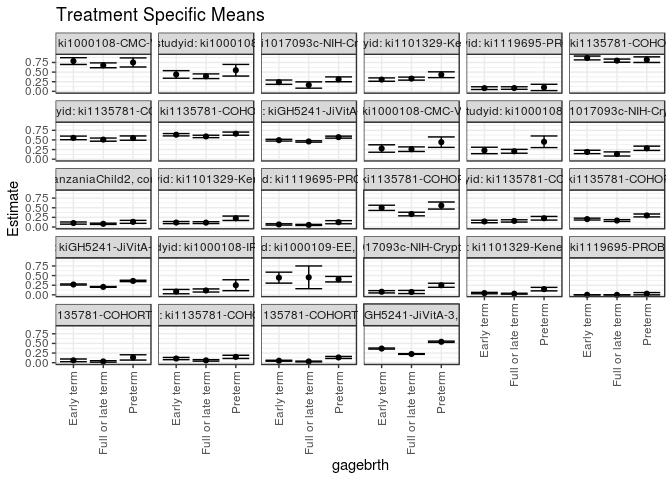

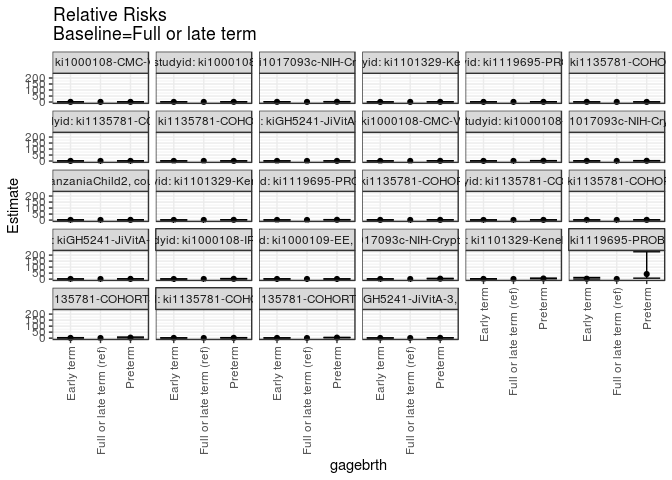

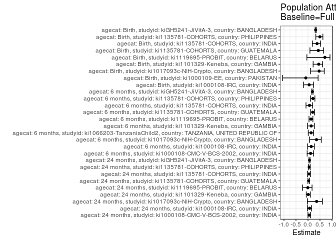

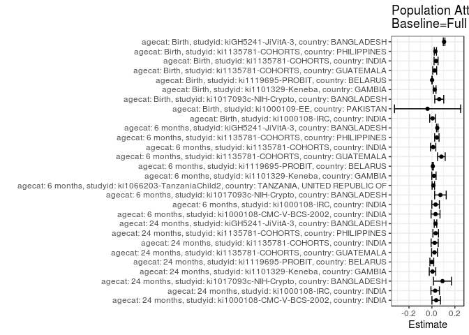

## Results Table

### Parameter: TSM

| agecat | studyid | country | intervention_level | baseline_level | estimate | ci_lower | ci_upper |
| --- | --- | --- | --- | --- | --- | --- | --- |
| Birth | ki1000108-IRC | INDIA | Full or late term | NA | 0.1134454 | 0.0730999 | 0.1537909 |
| Birth | ki1000108-IRC | INDIA | Preterm | NA | 0.2500000 | 0.1083597 | 0.3916403 |
| Birth | ki1000108-IRC | INDIA | Early term | NA | 0.0842105 | 0.0282919 | 0.1401292 |
| Birth | ki1000109-EE | PAKISTAN | Full or late term | NA | 0.4545455 | 0.1596783 | 0.7494126 |
| Birth | ki1000109-EE | PAKISTAN | Preterm | NA | 0.4065934 | 0.3350820 | 0.4781048 |
| Birth | ki1000109-EE | PAKISTAN | Early term | NA | 0.4468085 | 0.3043776 | 0.5892394 |
| Birth | ki1017093c-NIH-Crypto | BANGLADESH | Full or late term | NA | 0.0740741 | 0.0337180 | 0.1144301 |
| Birth | ki1017093c-NIH-Crypto | BANGLADESH | Preterm | NA | 0.2490272 | 0.1961201 | 0.3019343 |
| Birth | ki1017093c-NIH-Crypto | BANGLADESH | Early term | NA | 0.0798722 | 0.0498187 | 0.1099257 |
| Birth | ki1101329-Keneba | GAMBIA | Full or late term | NA | 0.0299728 | 0.0176332 | 0.0423123 |
| Birth | ki1101329-Keneba | GAMBIA | Preterm | NA | 0.1489362 | 0.1034019 | 0.1944705 |
| Birth | ki1101329-Keneba | GAMBIA | Early term | NA | 0.0457875 | 0.0282491 | 0.0633260 |
| Birth | ki1119695-PROBIT | BELARUS | Full or late term | NA | 0.0007044 | -0.0002055 | 0.0016144 |
| Birth | ki1119695-PROBIT | BELARUS | Preterm | NA | 0.0296610 | -0.0004610 | 0.0597831 |
| Birth | ki1119695-PROBIT | BELARUS | Early term | NA | 0.0022152 | 0.0011581 | 0.0032723 |
| Birth | ki1135781-COHORTS | GUATEMALA | Full or late term | NA | 0.0322581 | 0.0134899 | 0.0510262 |
| Birth | ki1135781-COHORTS | GUATEMALA | Preterm | NA | 0.1368421 | 0.0676760 | 0.2060082 |
| Birth | ki1135781-COHORTS | GUATEMALA | Early term | NA | 0.0607735 | 0.0259395 | 0.0956075 |
| Birth | ki1135781-COHORTS | INDIA | Full or late term | NA | 0.0596491 | 0.0401989 | 0.0790994 |
| Birth | ki1135781-COHORTS | INDIA | Preterm | NA | 0.1508772 | 0.1093062 | 0.1924482 |
| Birth | ki1135781-COHORTS | INDIA | Early term | NA | 0.1073059 | 0.0783097 | 0.1363022 |
| Birth | ki1135781-COHORTS | PHILIPPINES | Full or late term | NA | 0.0309278 | 0.0209807 | 0.0408749 |
| Birth | ki1135781-COHORTS | PHILIPPINES | Preterm | NA | 0.1355932 | 0.1092496 | 0.1619369 |
| Birth | ki1135781-COHORTS | PHILIPPINES | Early term | NA | 0.0503716 | 0.0380514 | 0.0626918 |
| Birth | kiGH5241-JiVitA-3 | BANGLADESH | Full or late term | NA | 0.2253289 | 0.2160473 | 0.2346106 |
| Birth | kiGH5241-JiVitA-3 | BANGLADESH | Preterm | NA | 0.5425343 | 0.5259816 | 0.5590871 |
| Birth | kiGH5241-JiVitA-3 | BANGLADESH | Early term | NA | 0.3666444 | 0.3528647 | 0.3804241 |
| 6 months | ki1000108-CMC-V-BCS-2002 | INDIA | Full or late term | NA | 0.2594340 | 0.2003456 | 0.3185224 |
| 6 months | ki1000108-CMC-V-BCS-2002 | INDIA | Preterm | NA | 0.4423077 | 0.3071214 | 0.5774940 |
| 6 months | ki1000108-CMC-V-BCS-2002 | INDIA | Early term | NA | 0.2771084 | 0.1806818 | 0.3735351 |

[output cut: 54 more lines]

### Parameter: E(Y)

| agecat | studyid | country | intervention_level | baseline_level | estimate | ci_lower | ci_upper |
| --- | --- | --- | --- | --- | --- | --- | --- |
| Birth | ki1000108-IRC | INDIA | NA | NA | 0.1192412 | 0.0861307 | 0.1523517 |
| Birth | ki1000109-EE | PAKISTAN | NA | NA | 0.4166667 | 0.3541635 | 0.4791698 |
| Birth | ki1017093c-NIH-Crypto | BANGLADESH | NA | NA | 0.1379781 | 0.1129774 | 0.1629789 |
| Birth | ki1101329-Keneba | GAMBIA | NA | NA | 0.0541254 | 0.0427281 | 0.0655227 |
| Birth | ki1119695-PROBIT | BELARUS | NA | NA | 0.0023758 | 0.0010936 | 0.0036580 |
| Birth | ki1135781-COHORTS | GUATEMALA | NA | NA | 0.0567261 | 0.0384591 | 0.0749931 |
| Birth | ki1135781-COHORTS | INDIA | NA | NA | 0.0959010 | 0.0798450 | 0.1119570 |
| Birth | ki1135781-COHORTS | PHILIPPINES | NA | NA | 0.0611772 | 0.0526341 | 0.0697204 |
| Birth | kiGH5241-JiVitA-3 | BANGLADESH | NA | NA | 0.3315456 | 0.3240495 | 0.3390416 |
| 6 months | ki1000108-CMC-V-BCS-2002 | INDIA | NA | NA | 0.2910663 | 0.2432023 | 0.3389303 |
| 6 months | ki1000108-IRC | INDIA | NA | NA | 0.2371134 | 0.1947393 | 0.2794875 |
| 6 months | ki1017093c-NIH-Crypto | BANGLADESH | NA | NA | 0.2097902 | 0.1799252 | 0.2396552 |
| 6 months | ki1066203-TanzaniaChild2 | TANZANIA, UNITED REPUBLIC OF | NA | NA | 0.0956385 | 0.0824215 | 0.1088554 |
| 6 months | ki1101329-Keneba | GAMBIA | NA | NA | 0.1317322 | 0.1138432 | 0.1496211 |
| 6 months | ki1119695-PROBIT | BELARUS | NA | NA | 0.0626864 | 0.0488489 | 0.0765239 |
| 6 months | ki1135781-COHORTS | GUATEMALA | NA | NA | 0.4193548 | 0.3831093 | 0.4556004 |
| 6 months | ki1135781-COHORTS | INDIA | NA | NA | 0.1692073 | 0.1489117 | 0.1895030 |
| 6 months | ki1135781-COHORTS | PHILIPPINES | NA | NA | 0.2113882 | 0.1959475 | 0.2268289 |
| 6 months | kiGH5241-JiVitA-3 | BANGLADESH | NA | NA | 0.2528420 | 0.2446204 | 0.2610636 |
| 24 months | ki1000108-CMC-V-BCS-2002 | INDIA | NA | NA | 0.7134670 | 0.6659628 | 0.7609713 |
| 24 months | ki1000108-IRC | INDIA | NA | NA | 0.4205128 | 0.3714576 | 0.4695680 |
| 24 months | ki1017093c-NIH-Crypto | BANGLADESH | NA | NA | 0.2568093 | 0.2190047 | 0.2946140 |
| 24 months | ki1101329-Keneba | GAMBIA | NA | NA | 0.3356401 | 0.3084071 | 0.3628732 |
| 24 months | ki1119695-PROBIT | BELARUS | NA | NA | 0.0852540 | 0.0554439 | 0.1150642 |
| 24 months | ki1135781-COHORTS | GUATEMALA | NA | NA | 0.8199697 | 0.7906576 | 0.8492819 |
| 24 months | ki1135781-COHORTS | INDIA | NA | NA | 0.5321101 | 0.5050591 | 0.5591611 |
| 24 months | ki1135781-COHORTS | PHILIPPINES | NA | NA | 0.6237624 | 0.6044733 | 0.6430515 |
| 24 months | kiGH5241-JiVitA-3 | BANGLADESH | NA | NA | 0.4910997 | 0.4777434 | 0.5044561 |

### Parameter: RR

| agecat | studyid | country | intervention_level | baseline_level | estimate | ci_lower | ci_upper |
| --- | --- | --- | --- | --- | --- | --- | --- |
| Birth | ki1000108-IRC | INDIA | Full or late term | Full or late term | 1.0000000 | 1.0000000 | 1.000000 |
| Birth | ki1000108-IRC | INDIA | Preterm | Full or late term | 2.2037037 | 1.1288592 | 4.301963 |
| Birth | ki1000108-IRC | INDIA | Early term | Full or late term | 0.7423002 | 0.3494922 | 1.576600 |
| Birth | ki1000109-EE | PAKISTAN | Full or late term | Full or late term | 1.0000000 | 1.0000000 | 1.000000 |
| Birth | ki1000109-EE | PAKISTAN | Preterm | Full or late term | 0.8945055 | 0.4567534 | 1.751799 |
| Birth | ki1000109-EE | PAKISTAN | Early term | Full or late term | 0.9829787 | 0.4771297 | 2.025125 |
| Birth | ki1017093c-NIH-Crypto | BANGLADESH | Full or late term | Full or late term | 1.0000000 | 1.0000000 | 1.000000 |
| Birth | ki1017093c-NIH-Crypto | BANGLADESH | Preterm | Full or late term | 3.3618677 | 1.8733542 | 6.033111 |
| Birth | ki1017093c-NIH-Crypto | BANGLADESH | Early term | Full or late term | 1.0782748 | 0.5561316 | 2.090650 |
| Birth | ki1101329-Keneba | GAMBIA | Full or late term | Full or late term | 1.0000000 | 1.0000000 | 1.000000 |
| Birth | ki1101329-Keneba | GAMBIA | Preterm | Full or late term | 4.9690522 | 2.9755587 | 8.298099 |
| Birth | ki1101329-Keneba | GAMBIA | Early term | Full or late term | 1.5276390 | 0.8705747 | 2.680621 |
| Birth | ki1119695-PROBIT | BELARUS | Full or late term | Full or late term | 1.0000000 | 1.0000000 | 1.000000 |
| Birth | ki1119695-PROBIT | BELARUS | Preterm | Full or late term | 42.1067797 | 7.7888005 | 227.632084 |
| Birth | ki1119695-PROBIT | BELARUS | Early term | Full or late term | 3.1446835 | 0.7332444 | 13.486683 |
| Birth | ki1135781-COHORTS | GUATEMALA | Full or late term | Full or late term | 1.0000000 | 1.0000000 | 1.000000 |
| Birth | ki1135781-COHORTS | GUATEMALA | Preterm | Full or late term | 4.2421053 | 1.9627721 | 9.168389 |
| Birth | ki1135781-COHORTS | GUATEMALA | Early term | Full or late term | 1.8839779 | 0.8324856 | 4.263584 |
| Birth | ki1135781-COHORTS | INDIA | Full or late term | Full or late term | 1.0000000 | 1.0000000 | 1.000000 |
| Birth | ki1135781-COHORTS | INDIA | Preterm | Full or late term | 2.5294118 | 1.6505151 | 3.876320 |
| Birth | ki1135781-COHORTS | INDIA | Early term | Full or late term | 1.7989525 | 1.1778748 | 2.747516 |
| Birth | ki1135781-COHORTS | PHILIPPINES | Full or late term | Full or late term | 1.0000000 | 1.0000000 | 1.000000 |
| Birth | ki1135781-COHORTS | PHILIPPINES | Preterm | Full or late term | 4.3841808 | 3.0109434 | 6.383727 |
| Birth | ki1135781-COHORTS | PHILIPPINES | Early term | Full or late term | 1.6286815 | 1.0873157 | 2.439589 |
| Birth | kiGH5241-JiVitA-3 | BANGLADESH | Full or late term | Full or late term | 1.0000000 | 1.0000000 | 1.000000 |
| Birth | kiGH5241-JiVitA-3 | BANGLADESH | Preterm | Full or late term | 2.4077436 | 2.2857043 | 2.536299 |
| Birth | kiGH5241-JiVitA-3 | BANGLADESH | Early term | Full or late term | 1.6271517 | 1.5416273 | 1.717421 |
| 6 months | ki1000108-CMC-V-BCS-2002 | INDIA | Full or late term | Full or late term | 1.0000000 | 1.0000000 | 1.000000 |
| 6 months | ki1000108-CMC-V-BCS-2002 | INDIA | Preterm | Full or late term | 1.7048951 | 1.1645510 | 2.495955 |
| 6 months | ki1000108-CMC-V-BCS-2002 | INDIA | Early term | Full or late term | 1.0681271 | 0.7047033 | 1.618973 |

[output cut: 54 more lines]

### Parameter: PAR

| agecat | studyid | country | intervention_level | baseline_level | estimate | ci_lower | ci_upper |
| --- | --- | --- | --- | --- | --- | --- | --- |
| Birth | ki1000108-IRC | INDIA | Full or late term | NA | 0.0057958 | -0.0191902 | 0.0307818 |
| Birth | ki1000109-EE | PAKISTAN | Full or late term | NA | -0.0378788 | -0.3257731 | 0.2500156 |
| Birth | ki1017093c-NIH-Crypto | BANGLADESH | Full or late term | NA | 0.0639041 | 0.0247532 | 0.1030549 |
| Birth | ki1101329-Keneba | GAMBIA | Full or late term | NA | 0.0241527 | 0.0125500 | 0.0357554 |
| Birth | ki1119695-PROBIT | BELARUS | Full or late term | NA | 0.0016714 | 0.0003113 | 0.0030314 |
| Birth | ki1135781-COHORTS | GUATEMALA | Full or late term | NA | 0.0244680 | 0.0072466 | 0.0416894 |
| Birth | ki1135781-COHORTS | INDIA | Full or late term | NA | 0.0362519 | 0.0188576 | 0.0536461 |
| Birth | ki1135781-COHORTS | PHILIPPINES | Full or late term | NA | 0.0302494 | 0.0204638 | 0.0400350 |
| Birth | kiGH5241-JiVitA-3 | BANGLADESH | Full or late term | NA | 0.1062166 | 0.0991026 | 0.1133307 |
| 6 months | ki1000108-CMC-V-BCS-2002 | INDIA | Full or late term | NA | 0.0316323 | -0.0073061 | 0.0705708 |
| 6 months | ki1000108-IRC | INDIA | Full or late term | NA | 0.0322941 | -0.0005901 | 0.0651784 |
| 6 months | ki1017093c-NIH-Crypto | BANGLADESH | Full or late term | NA | 0.0743063 | 0.0239228 | 0.1246898 |
| 6 months | ki1066203-TanzaniaChild2 | TANZANIA, UNITED REPUBLIC OF | Full or late term | NA | 0.0125194 | 0.0016639 | 0.0233748 |
| 6 months | ki1101329-Keneba | GAMBIA | Full or late term | NA | 0.0177504 | -0.0008217 | 0.0363225 |
| 6 months | ki1119695-PROBIT | BELARUS | Full or late term | NA | 0.0079911 | 0.0026427 | 0.0133394 |
| 6 months | ki1135781-COHORTS | GUATEMALA | Full or late term | NA | 0.0825939 | 0.0492416 | 0.1159462 |
| 6 months | ki1135781-COHORTS | INDIA | Full or late term | NA | 0.0107566 | -0.0123298 | 0.0338430 |
| 6 months | ki1135781-COHORTS | PHILIPPINES | Full or late term | NA | 0.0431002 | 0.0240927 | 0.0621078 |
| 6 months | kiGH5241-JiVitA-3 | BANGLADESH | Full or late term | NA | 0.0467906 | 0.0402554 | 0.0533258 |
| 24 months | ki1000108-CMC-V-BCS-2002 | INDIA | Full or late term | NA | 0.0374107 | 0.0002258 | 0.0745956 |
| 24 months | ki1000108-IRC | INDIA | Full or late term | NA | 0.0285128 | -0.0085117 | 0.0655374 |
| 24 months | ki1017093c-NIH-Crypto | BANGLADESH | Full or late term | NA | 0.0922524 | 0.0143531 | 0.1701517 |
| 24 months | ki1101329-Keneba | GAMBIA | Full or late term | NA | 0.0052990 | -0.0229342 | 0.0335323 |
| 24 months | ki1119695-PROBIT | BELARUS | Full or late term | NA | -0.0007144 | -0.0173754 | 0.0159467 |
| 24 months | ki1135781-COHORTS | GUATEMALA | Full or late term | NA | 0.0226364 | -0.0025823 | 0.0478551 |
| 24 months | ki1135781-COHORTS | INDIA | Full or late term | NA | 0.0241455 | -0.0068898 | 0.0551807 |
| 24 months | ki1135781-COHORTS | PHILIPPINES | Full or late term | NA | 0.0331440 | 0.0087305 | 0.0575576 |
| 24 months | kiGH5241-JiVitA-3 | BANGLADESH | Full or late term | NA | 0.0314279 | 0.0203032 | 0.0425527 |

### Parameter: PAF

| agecat | studyid | country | intervention_level | baseline_level | estimate | ci_lower | ci_upper |
| --- | --- | --- | --- | --- | --- | --- | --- |
| Birth | ki1000108-IRC | INDIA | Full or late term | NA | 0.0486058 | -0.1854004 | 0.2364176 |
| Birth | ki1000109-EE | PAKISTAN | Full or late term | NA | -0.0909091 | -1.0553535 | 0.4209840 |
| Birth | ki1017093c-NIH-Crypto | BANGLADESH | Full or late term | NA | 0.4631463 | 0.1068457 | 0.6773101 |
| Birth | ki1101329-Keneba | GAMBIA | Full or late term | NA | 0.4462351 | 0.2137384 | 0.6099828 |
| Birth | ki1119695-PROBIT | BELARUS | Full or late term | NA | 0.7035016 | -0.0454955 | 0.9159142 |
| Birth | ki1135781-COHORTS | GUATEMALA | Full or late term | NA | 0.4313364 | 0.0819272 | 0.6477640 |
| Birth | ki1135781-COHORTS | INDIA | Full or late term | NA | 0.3780136 | 0.1805054 | 0.5279199 |
| Birth | ki1135781-COHORTS | PHILIPPINES | Full or late term | NA | 0.4944553 | 0.3260309 | 0.6207906 |
| Birth | kiGH5241-JiVitA-3 | BANGLADESH | Full or late term | NA | 0.3203681 | 0.2987550 | 0.3413150 |
| 6 months | ki1000108-CMC-V-BCS-2002 | INDIA | Full or late term | NA | 0.1086774 | -0.0352902 | 0.2326248 |
| 6 months | ki1000108-IRC | INDIA | Full or late term | NA | 0.1361970 | -0.0130777 | 0.2634764 |
| 6 months | ki1017093c-NIH-Crypto | BANGLADESH | Full or late term | NA | 0.3541935 | 0.0683540 | 0.5523343 |
| 6 months | ki1066203-TanzaniaChild2 | TANZANIA, UNITED REPUBLIC OF | Full or late term | NA | 0.1309029 | 0.0109997 | 0.2362695 |
| 6 months | ki1101329-Keneba | GAMBIA | Full or late term | NA | 0.1347462 | -0.0173400 | 0.2640964 |
| 6 months | ki1119695-PROBIT | BELARUS | Full or late term | NA | 0.1274770 | 0.0429774 | 0.2045158 |
| 6 months | ki1135781-COHORTS | GUATEMALA | Full or late term | NA | 0.1969547 | 0.1130293 | 0.2729391 |
| 6 months | ki1135781-COHORTS | INDIA | Full or late term | NA | 0.0635706 | -0.0831558 | 0.1904212 |
| 6 months | ki1135781-COHORTS | PHILIPPINES | Full or late term | NA | 0.2038914 | 0.1094932 | 0.2882829 |
| 6 months | kiGH5241-JiVitA-3 | BANGLADESH | Full or late term | NA | 0.1850587 | 0.1588952 | 0.2104084 |
| 24 months | ki1000108-CMC-V-BCS-2002 | INDIA | Full or late term | NA | 0.0524351 | -0.0016012 | 0.1035561 |
| 24 months | ki1000108-IRC | INDIA | Full or late term | NA | 0.0678049 | -0.0246711 | 0.1519350 |
| 24 months | ki1017093c-NIH-Crypto | BANGLADESH | Full or late term | NA | 0.3592252 | -0.0245831 | 0.5992591 |
| 24 months | ki1101329-Keneba | GAMBIA | Full or late term | NA | 0.0157878 | -0.0720290 | 0.0964110 |
| 24 months | ki1119695-PROBIT | BELARUS | Full or late term | NA | -0.0083791 | -0.2243974 | 0.1695275 |
| 24 months | ki1135781-COHORTS | GUATEMALA | Full or late term | NA | 0.0276064 | -0.0037690 | 0.0580010 |
| 24 months | ki1135781-COHORTS | INDIA | Full or late term | NA | 0.0453769 | -0.0148234 | 0.1020060 |
| 24 months | ki1135781-COHORTS | PHILIPPINES | Full or late term | NA | 0.0531357 | 0.0130995 | 0.0915477 |
| 24 months | kiGH5241-JiVitA-3 | BANGLADESH | Full or late term | NA | 0.0639950 | 0.0408646 | 0.0865675 |